# **Predicting Credit Card Approval**

*By Daniel Heffron, Jainam Patel, and Sash Sujith*

# **Introduction**

Credit card approval is a task that requires consideration of multiple factors. A manual approval process would be menial, time consuming, and inefficient overall. With this project, our group is trying to create a process to automate the credit card approval process.

We are looking at a dataset from [kaggle.com](https://www.kaggle.com/datasets/rikdifos/credit-card-approval-prediction) that contains two CSV files. The first file (*application_record.csv*) contains personal information about applicants. The second file (*credit_record.csv*) contains the credit records of applicants. We will examine the association between 1) factors such as age, number of children, income, etc. and 2) approval. We will also create our own model to predict whether or not an applicant is approvable or not. The goal of the project is to find the factors that influence the credit card approval decision the most.

# **Collecting and Handling Data**

The first thing we did was read in the CSV file that contained applicants' personal information. Then, we dropped any rows with missing values from *application_record.csv*. These entries are useless for our project as we need to be able to look at the applicant as a whole to determine if they’re approvable or not.

```python
import pandas as pd
import builtins
```

```python
# Below we are reading the csv files

app_rec = pd.read_csv("application_record.csv")
# app_rec = app_rec.drop(columns = ["FLAG_MOBIL", "FLAG_WORK_PHONE", "FLAG_PHONE", "FLAG_EMAIL"])

# before drop: 438557 rows
# Drop rows with na in any column
app_rec = app_rec.dropna()
# after drop: 304354 rows

# printing the dataset
app_rec
```

|  | ID | CODE_GENDER | FLAG_OWN_CAR | FLAG_OWN_REALTY | CNT_CHILDREN | AMT_INCOME_TOTAL | NAME_INCOME_TYPE | NAME_EDUCATION_TYPE | NAME_FAMILY_STATUS | NAME_HOUSING_TYPE | DAYS_BIRTH | DAYS_EMPLOYED | FLAG_MOBIL | FLAG_WORK_PHONE | FLAG_PHONE | FLAG_EMAIL | OCCUPATION_TYPE | CNT_FAM_MEMBERS |
| --- | --- | --- | --- | --- | --- | --- | --- | --- | --- | --- | --- | --- | --- | --- | --- | --- | --- | --- |
| 2 | 5008806 | M | Y | Y | 0 | 112500.0 | Working | Secondary / secondary special | Married | House / apartment | -21474 | -1134 | 1 | 0 | 0 | 0 | Security staff | 2.0 |
| 3 | 5008808 | F | N | Y | 0 | 270000.0 | Commercial associate | Secondary / secondary special | Single / not married | House / apartment | -19110 | -3051 | 1 | 0 | 1 | 1 | Sales staff | 1.0 |
| 4 | 5008809 | F | N | Y | 0 | 270000.0 | Commercial associate | Secondary / secondary special | Single / not married | House / apartment | -19110 | -3051 | 1 | 0 | 1 | 1 | Sales staff | 1.0 |
| 5 | 5008810 | F | N | Y | 0 | 270000.0 | Commercial associate | Secondary / secondary special | Single / not married | House / apartment | -19110 | -3051 | 1 | 0 | 1 | 1 | Sales staff | 1.0 |
| 6 | 5008811 | F | N | Y | 0 | 270000.0 | Commercial associate | Secondary / secondary special | Single / not married | House / apartment | -19110 | -3051 | 1 | 0 | 1 | 1 | Sales staff | 1.0 |
| ... | ... | ... | ... | ... | ... | ... | ... | ... | ... | ... | ... | ... | ... | ... | ... | ... | ... | ... |
| 438541 | 6837707 | M | N | Y | 0 | 202500.0 | Working | Higher education | Civil marriage | House / apartment | -13510 | -2309 | 1 | 1 | 0 | 0 | Laborers | 2.0 |
| 438548 | 6839936 | M | Y | Y | 1 | 135000.0 | Working | Secondary / secondary special | Married | House / apartment | -12569 | -2095 | 1 | 0 | 0 | 0 | Laborers | 3.0 |
| 438553 | 6840222 | F | N | N | 0 | 103500.0 | Working | Secondary / secondary special | Single / not married | House / apartment | -15939 | -3007 | 1 | 0 | 0 | 0 | Laborers | 1.0 |
| 438554 | 6841878 | F | N | N | 0 | 54000.0 | Commercial associate | Higher education | Single / not married | With parents | -8169 | -372 | 1 | 1 | 0 | 0 | Sales staff | 1.0 |
| 438556 | 6842885 | F | N | Y | 0 | 121500.0 | Working | Secondary / secondary special | Married | House / apartment | -18858 | -1201 | 1 | 0 | 1 | 0 | Sales staff | 2.0 |

304354 rows × 18 columns

Then, we read in the data from the *credit_record.csv*. There are 7 possible values for the “Status” column. A “0” denotes a balance that is 1-29 days past. “1” is 30-59 days past due. “2” is 60-89 days overdue. “3” is 90-119 days overdue. “4” is 120-149 days overdue. “5” is overdue or bad debts, write-offs for more than 150 days. A “C” means paid off that month and an “X” is no loan for the month.

For the data from *credit_record.csv*, we realized that the credit history for each applicant varied quite a bit. Some applicants had a credit history of 4 months, while others had upwards of 15 months. To make the data more readable, we decided to find an average status for each applicant.

```python
credit_rec = pd.read_csv("credit_record.csv")
credit_rec = credit_rec.drop(columns = ["MONTHS_BALANCE"])

# [ C,  X, 0, 1, 2, 3, 4, 5] => [-2, -1, 0, 1, 2, 3, 4, 5]
# Convert all entires in "STATUS" column to integer values for computing the average status of each ID
credit_rec.loc[credit_rec["STATUS"] == "C", "STATUS"] = -2
credit_rec.loc[credit_rec["STATUS"] == "X", "STATUS"] = -1
credit_rec.loc[credit_rec["STATUS"] == "0", "STATUS"] = 0
credit_rec.loc[credit_rec["STATUS"] == "1", "STATUS"] = 1
credit_rec.loc[credit_rec["STATUS"] == "2", "STATUS"] = 2
credit_rec.loc[credit_rec["STATUS"] == "3", "STATUS"] = 3
credit_rec.loc[credit_rec["STATUS"] == "4", "STATUS"] = 4
credit_rec.loc[credit_rec["STATUS"] == "5", "STATUS"] = 5

# Get mean status for each ID
credit_rec = credit_rec.groupby(['ID']).mean()
credit_rec = credit_rec.reset_index()
# Round mean status to nearest integer for interpretation (the smaller the integer the better the score)
credit_rec = credit_rec.round(decimals = 0)
credit_rec = credit_rec.astype({"STATUS":int})

credit_rec
```

|  | ID | STATUS |
| --- | --- | --- |
| 0 | 5001711 | 0 |
| 1 | 5001712 | -1 |
| 2 | 5001713 | -1 |
| 3 | 5001714 | -1 |
| 4 | 5001715 | -1 |
| ... | ... | ... |
| 45980 | 5150482 | -1 |
| 45981 | 5150483 | -1 |
| 45982 | 5150484 | 0 |
| 45983 | 5150485 | 0 |
| 45984 | 5150487 | -2 |

45985 rows × 2 columns

The data is ready for use. We merged both tables by ID.

```python
# Only analyze those rows with an ID present in both tables
merged = pd.merge(app_rec, credit_rec, how ='inner', on =['ID'])
merged

# Note: 25134 matcing rows we can work with
```

|  | ID | CODE_GENDER | FLAG_OWN_CAR | FLAG_OWN_REALTY | CNT_CHILDREN | AMT_INCOME_TOTAL | NAME_INCOME_TYPE | NAME_EDUCATION_TYPE | NAME_FAMILY_STATUS | NAME_HOUSING_TYPE | DAYS_BIRTH | DAYS_EMPLOYED | FLAG_MOBIL | FLAG_WORK_PHONE | FLAG_PHONE | FLAG_EMAIL | OCCUPATION_TYPE | CNT_FAM_MEMBERS | STATUS |
| --- | --- | --- | --- | --- | --- | --- | --- | --- | --- | --- | --- | --- | --- | --- | --- | --- | --- | --- | --- |
| 0 | 5008806 | M | Y | Y | 0 | 112500.0 | Working | Secondary / secondary special | Married | House / apartment | -21474 | -1134 | 1 | 0 | 0 | 0 | Security staff | 2.0 | -1 |
| 1 | 5008808 | F | N | Y | 0 | 270000.0 | Commercial associate | Secondary / secondary special | Single / not married | House / apartment | -19110 | -3051 | 1 | 0 | 1 | 1 | Sales staff | 1.0 | -1 |
| 2 | 5008809 | F | N | Y | 0 | 270000.0 | Commercial associate | Secondary / secondary special | Single / not married | House / apartment | -19110 | -3051 | 1 | 0 | 1 | 1 | Sales staff | 1.0 | -1 |
| 3 | 5008810 | F | N | Y | 0 | 270000.0 | Commercial associate | Secondary / secondary special | Single / not married | House / apartment | -19110 | -3051 | 1 | 0 | 1 | 1 | Sales staff | 1.0 | -1 |
| 4 | 5008811 | F | N | Y | 0 | 270000.0 | Commercial associate | Secondary / secondary special | Single / not married | House / apartment | -19110 | -3051 | 1 | 0 | 1 | 1 | Sales staff | 1.0 | -2 |
| ... | ... | ... | ... | ... | ... | ... | ... | ... | ... | ... | ... | ... | ... | ... | ... | ... | ... | ... | ... |
| 25129 | 5149828 | M | Y | Y | 0 | 315000.0 | Working | Secondary / secondary special | Married | House / apartment | -17348 | -2420 | 1 | 0 | 0 | 0 | Managers | 2.0 | 1 |
| 25130 | 5149834 | F | N | Y | 0 | 157500.0 | Commercial associate | Higher education | Married | House / apartment | -12387 | -1325 | 1 | 0 | 1 | 1 | Medicine staff | 2.0 | 2 |
| 25131 | 5149838 | F | N | Y | 0 | 157500.0 | Pensioner | Higher education | Married | House / apartment | -12387 | -1325 | 1 | 0 | 1 | 1 | Medicine staff | 2.0 | 1 |
| 25132 | 5150049 | F | N | Y | 0 | 283500.0 | Working | Secondary / secondary special | Married | House / apartment | -17958 | -655 | 1 | 0 | 0 | 0 | Sales staff | 2.0 | 0 |
| 25133 | 5150337 | M | N | Y | 0 | 112500.0 | Working | Secondary / secondary special | Single / not married | Rented apartment | -9188 | -1193 | 1 | 0 | 0 | 0 | Laborers | 1.0 | 0 |

25134 rows × 19 columns

# **Creating a Model**

## Linear Discriminant Analysis

```python
from sklearn.model_selection import train_test_split
from sklearn.discriminant_analysis import LinearDiscriminantAnalysis
import sklearn.model_selection as ms
import sklearn.metrics as met
import pandas as pd
import numpy as np
```

To begin the Linear Discriminant Analysis on our dataset we must first map all non-numeric values to a corresponding numeric value. We start with the Male/Female and Yes/No identifiers, M/F and Y/N respectively:

- M/F will map to 1/0
- Y/N will map to 1/0

From there we must iterate over the rest of our non-numeric columns in our dataset and do the same. Our remaing non-numeric columns and their corresponding mappings are as follows:

```
NAME_INCOME_TYPE:
['Working', 'Commercial associate', 'State servant', 'Student', 'Pensioner']
=> [0, 1, 2, 3, 4]
NAME_EDUCATION_TYPE:
['Secondary / secondary special', 'Higher education', 'Incomplete higher', 'Lower secondary', 'Academic degree']
=> [0, 1, 2, 3, 4]
NAME_FAMILY_STATUS:
['Married', 'Single / not married', 'Civil marriage', 'Separated', 'Widow']
=> [0, 1, 2, 3, 4]
NAME_HOUSING_TYPE:
['House / apartment', 'Rented apartment', 'Municipal apartment', 'With parents', 'Co-op apartment', 'Office apartment']
=> [0, 1, 2, 3, 4, 5]
OCCUPATION_TYPE:
['Security staff', 'Sales staff', 'Accountants', 'Laborers', 'Managers', 'Drivers',
'Core staff', 'High skill tech staff', 'Cleaning staff', 'Private service staff', 'Cooking staff', 'Low-skill Laborers',
'Medicine staff', 'Secretaries', 'Waiters/barmen staff', 'HR staff', 'Realty agents', 'IT staff']
=> [0, 1, 2, 3, 4, 5, 6, 7, 8, 9 , 10, 11, 12, 13, 14, 15, 16, 17]
```

```python
# Get independent variables
new_app = merged.drop(columns = ["STATUS"])
# Map non-numeric values to int for analysis
new_app = new_app.replace(["M", "F", "Y", "N"], [1, 0, 1, 0])
columns = ["NAME_INCOME_TYPE", "NAME_EDUCATION_TYPE", "NAME_FAMILY_STATUS", "NAME_HOUSING_TYPE", "OCCUPATION_TYPE"]

# Mapping the data of columns with string values to an identifier integer
for i in builtins.range(len(columns)):
    vals = new_app[columns[i]].unique().tolist()
    new_vals = list(builtins.range(0, len(vals)))
    new_app = new_app.replace(vals, new_vals)

# Get dependent variable
new_credit = merged[["STATUS"]]["STATUS"].tolist()
```

Now we can run the analysis and test how good our algorithm was at predicting the average time a given person will take to pay off their credit card debt. Recall that these average times are represented as a value from the list [-2, -1, 0, 1, 2, 3, 4, 5] with the smaller the number the sooner and "-2" representing an on-time payment.

```python
app_train, app_test, credit_train, credit_test = ms.train_test_split(new_app, new_credit, random_state = 1)

# Fit classifier using training data
clf = LinearDiscriminantAnalysis()
clf.fit(app_train, credit_train)

# Use classifier on testing data
testing_results = clf.predict(app_test).tolist()

# Test accuracy of classifier
print("Accuracy Score: " +str(met.accuracy_score(credit_test, testing_results)))
```

```
Accuracy Score: 0.4011775938892425
```

After testing our algorithm, we can see that we predicted the correct credit score from our applicant testing set with only ~40.12% of the time. While this level of accuracy seems poor, it's effectiveness is much higher relative to that of random guessing. Keep in mind that our algorithm must select from a pool of 8 possible integer values in the range [-2, 5]. This means chance of randomly guessing the right credit score for an applicant is 1 out of 8, or 12.5%. Therefore, our algorithm is statistically over 3 times more accurate than random guessing.

Now lets see how good it is at predicting approval rate. To do this we will map all values from [-2, -1, 0, 1] in credit_test and testing_results to 'approved', and all values from [2, 3, 4, 5] in credit_test and testing_results to 'not'.

```python
for i in builtins.range(len(credit_test)):
  if credit_test[i] <= 1:
    credit_test[i] = 'approved'
  else:
    credit_test[i] = 'not'

for i in builtins.range(len(testing_results)):
  if testing_results[i] <= 1:
    testing_results[i] = 'approved'
  else:
    testing_results[i] = 'not'

print("Accuracy Score: " +str(met.accuracy_score(credit_test, testing_results)))
```

```
Accuracy Score: 0.9964990451941439
```

Notice the significant increase in our algorithms accuracy -- ~99.65%. This tells us that we be much more confident the algorithms ability to accurately predict whether or not a given applicant will be approved.

## Converting Age and Employment to Years

In the dataset, age is originally given as a negative number of days in the column "DAYS_BIRTH". The date of birth was determined by counting backward from the current day. For example, if an entry has a 0 in the "DAYS_BIRTH" column, it means they were born today (-1 would mean they were born yesterday).

In order to avoid any potential confusion, we decided to create a new column "AGE_YEARS" that would have the ages of every applicant in years (not days). To fill the new column, we took all the values in the original "DAYS_BIRTH" column and divided them by -365.

We do the same for the "DAYS_EMPLOYED" column, converting it to "YEARS_EMPLOYED".

```python
merged["STATUS"].replace({-2: "approved", -1: "approved", 0: "approved", 1: "approved", 2: "not", 3: "not", 4: "not", 5: "not"}, inplace=True)

merged['DAYS_BIRTH'] = round(merged['DAYS_BIRTH']/-365,0)
merged.rename(columns={'DAYS_BIRTH':'AGE_YEARS'}, inplace = True)
merged = merged.astype({"AGE_YEARS":int})

merged['DAYS_EMPLOYED'] = round(merged['DAYS_EMPLOYED']/-365,0)
merged.rename(columns={'DAYS_EMPLOYED':'YEARS_EMPLOYED'}, inplace = True)
merged = merged.astype({"YEARS_EMPLOYED":int})

merged
```

|  | ID | CODE_GENDER | FLAG_OWN_CAR | FLAG_OWN_REALTY | CNT_CHILDREN | AMT_INCOME_TOTAL | NAME_INCOME_TYPE | NAME_EDUCATION_TYPE | NAME_FAMILY_STATUS | NAME_HOUSING_TYPE | AGE_YEARS | YEARS_EMPLOYED | FLAG_MOBIL | FLAG_WORK_PHONE | FLAG_PHONE | FLAG_EMAIL | OCCUPATION_TYPE | CNT_FAM_MEMBERS | STATUS |
| --- | --- | --- | --- | --- | --- | --- | --- | --- | --- | --- | --- | --- | --- | --- | --- | --- | --- | --- | --- |
| 0 | 5008806 | M | Y | Y | 0 | 112500.0 | Working | Secondary / secondary special | Married | House / apartment | 59 | 3 | 1 | 0 | 0 | 0 | Security staff | 2.0 | approved |
| 1 | 5008808 | F | N | Y | 0 | 270000.0 | Commercial associate | Secondary / secondary special | Single / not married | House / apartment | 52 | 8 | 1 | 0 | 1 | 1 | Sales staff | 1.0 | approved |
| 2 | 5008809 | F | N | Y | 0 | 270000.0 | Commercial associate | Secondary / secondary special | Single / not married | House / apartment | 52 | 8 | 1 | 0 | 1 | 1 | Sales staff | 1.0 | approved |
| 3 | 5008810 | F | N | Y | 0 | 270000.0 | Commercial associate | Secondary / secondary special | Single / not married | House / apartment | 52 | 8 | 1 | 0 | 1 | 1 | Sales staff | 1.0 | approved |
| 4 | 5008811 | F | N | Y | 0 | 270000.0 | Commercial associate | Secondary / secondary special | Single / not married | House / apartment | 52 | 8 | 1 | 0 | 1 | 1 | Sales staff | 1.0 | approved |
| ... | ... | ... | ... | ... | ... | ... | ... | ... | ... | ... | ... | ... | ... | ... | ... | ... | ... | ... | ... |
| 25129 | 5149828 | M | Y | Y | 0 | 315000.0 | Working | Secondary / secondary special | Married | House / apartment | 48 | 7 | 1 | 0 | 0 | 0 | Managers | 2.0 | approved |
| 25130 | 5149834 | F | N | Y | 0 | 157500.0 | Commercial associate | Higher education | Married | House / apartment | 34 | 4 | 1 | 0 | 1 | 1 | Medicine staff | 2.0 | not |
| 25131 | 5149838 | F | N | Y | 0 | 157500.0 | Pensioner | Higher education | Married | House / apartment | 34 | 4 | 1 | 0 | 1 | 1 | Medicine staff | 2.0 | approved |
| 25132 | 5150049 | F | N | Y | 0 | 283500.0 | Working | Secondary / secondary special | Married | House / apartment | 49 | 2 | 1 | 0 | 0 | 0 | Sales staff | 2.0 | approved |
| 25133 | 5150337 | M | N | Y | 0 | 112500.0 | Working | Secondary / secondary special | Single / not married | Rented apartment | 25 | 3 | 1 | 0 | 0 | 0 | Laborers | 1.0 | approved |

25134 rows × 19 columns

# **Data Visualization, Hypothesis Testing, and Analysis**

There are many factors to look into, but many seem not nearly as important as others. So, for this project we will be looking at 5 specific factors that we believe are the most influential in the approval decision process: age, income, work experience, education level, and marital status. Of all these, we believe that income will be the most important factor of the five.

```python
import matplotlib.pyplot as plt
import seaborn as sns
import numpy as np
from collections import defaultdict
from statsmodels.formula.api import ols
import warnings
warnings.filterwarnings('ignore')
```

## Age

First, we will explore the possible relationship between age and approval rate. Intuitively, we believe applicants between the ages of 25 and 60 are more likely to be approved since these applicants are more likely to have stable jobs and decent credit histories.

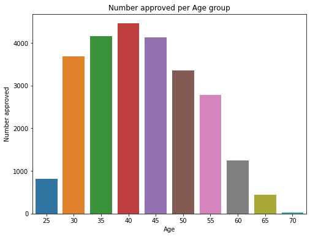

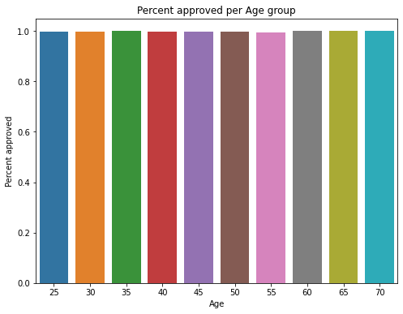

```python
age_ranges = list(builtins.range(0, round(merged['AGE_YEARS'].max()+5), 5))
d_approvals = defaultdict(int)
d_totals = defaultdict(int)
for idx, row in merged.iterrows():
  age = row["AGE_YEARS"];
  approval = row["STATUS"];
  for val in age_ranges:
    if age <= val:
      d_totals[val] += 1
      if approval == "approved":
        d_approvals[val] += 1
      break

# Raw numbers graph
age_x = list(d_approvals.keys())
age_y = list(d_approvals.values())

plt.figure(figsize = (8,6))
sns.barplot(age_x, age_y)
plt.xlabel('Age')
plt.ylabel('Number approved')
plt.title('Number approved per Age group')
plt.show()

print("\n")

# Percent graph
d_percent = {}
for key in d_totals.keys():
  d_percent[key] = d_approvals[key] / d_totals[key]

age_x = list(d_percent.keys())
age_y = list(d_percent.values())

plt.figure(figsize = (8,6))
sns.barplot(age_x, age_y)
plt.xlabel('Age')
plt.ylabel('Percent approved')
plt.title('Percent approved per Age group')
plt.show()
```

For our first graph, we looked at the number of approval depending on the age. At first glance, it seems like our prior beliefs are confirmed by this graph. But then we realized that this graph is not a proper representation of the data because there’s a large chance that most of the people that apply for credit cards are in the age range of 25 to 60; so there is a bias in the graph. To get a better insight into the data, we decided to create a second graph that compares approval rate per age group.

The second graph shows us that for every age group, the approval rate ranges from 95% to 100%. This incredibly high approval rate across the board led us to two possible conclusions. Either this graph is another representation that’s not exactly apt for the data or there is nearly no correlation between age and approval rate.

```
AxesSubplot(0.125,0.125;0.775x0.755)
                            OLS Regression Results
==============================================================================
Dep. Variable:        PercentApproved   R-squared:                       0.078
Model:                            OLS   Adj. R-squared:                 -0.037
Method:                 Least Squares   F-statistic:                    0.6799
Date:                Mon, 16 May 2022   Prob (F-statistic):              0.434
Time:                        19:31:33   Log-Likelihood:                 51.109
No. Observations:                  10   AIC:                            -98.22
Df Residuals:                       8   BIC:                            -97.61
Df Model:                           1
Covariance Type:            nonrobust
==============================================================================
                 coef    std err          t      P>|t|      [0.025      0.975]
------------------------------------------------------------------------------
Intercept      0.9969      0.002    559.213      0.000       0.993       1.001
AgeGroup    2.962e-05   3.59e-05      0.825      0.434   -5.32e-05       0.000
==============================================================================
Omnibus:                       13.437   Durbin-Watson:                   2.095
Prob(Omnibus):                  0.001   Jarque-Bera (JB):                6.532
Skew:                          -1.682   Prob(JB):                       0.0382
Kurtosis:                       5.089   Cond. No.                         172.
==============================================================================

Warnings:
[1] Standard Errors assume that the covariance matrix of the errors is correctly specified.
```

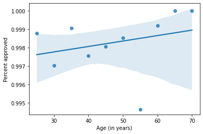

```python
age_graph = sns.regplot(age_x, age_y, fit_reg=True)
age_graph.set_xlabel("Age (in years)", fontsize = 10)
age_graph.set_ylabel("Percent approved", fontsize = 10)
print(age_graph)

age_table = pd.DataFrame(d_percent.items(), columns=['AgeGroup', 'PercentApproved'])
age_regr = ols(formula = "PercentApproved ~ AgeGroup", data = age_table).fit()
print(age_regr.summary())
```

We then modeled the data using a linear regression and we found that the coefficient slope number is 2.962e-05. This is incredibly small. There is a very, very weak correlation between age and approval rate that makes it seem like the younger you are the less chances of you getting approved.

## Income

Now we will explore the possible relationship between income and approval rate. Our hunch is that those with higher incomes are more likely to be approved for a credit card.

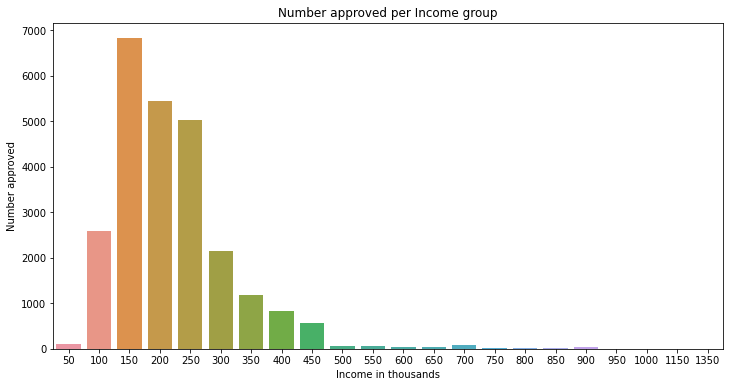

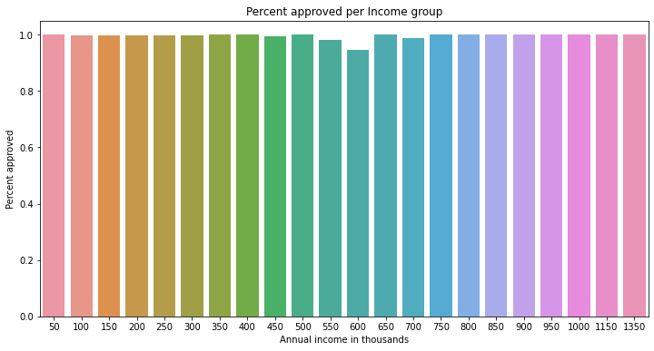

```python
income_ranges = list(builtins.range(50, round(merged['AMT_INCOME_TOTAL'].max()/1000), 50))
d_approvals = defaultdict(int)
d_totals = defaultdict(int)
for idx, row in merged.iterrows():
  income = row["AMT_INCOME_TOTAL"]/1000;
  approval = row["STATUS"];
  for val in income_ranges:
    if income <= val:
      d_totals[val] += 1
      if approval == "approved":
        d_approvals[val] += 1
      break


# Raw Numbers graph
income_x = list(d_approvals.keys())
income_y = list(d_approvals.values())

plt.figure(figsize = (12,6))
sns.barplot(income_x, income_y)
plt.xlabel('Income in thousands')
plt.ylabel('Number approved')
plt.title('Number approved per Income group')
plt.show()

print("\n")

# Percent graph
d_percent = {}
for key in d_totals.keys():
  d_percent[key] = d_approvals[key] / d_totals[key]

income_x = list(d_percent.keys())
income_y = list(d_percent.values())

plt.figure(figsize = (12,6))
sns.barplot(income_x, income_y)
plt.xlabel('Annual income in thousands')
plt.ylabel('Percent approved')
plt.title('Percent approved per Income group')
plt.show()
```

For our first graph, we wanted to get an idea of how many applicants were in a certain annual income bracket (similar to the first graph we created when looking at age). We found that the 100k to 150k range had the greatest number of accepted applicants.

However, not to be misled, we created another graph to see the percentage of approved applicants in each income bracket. In this graph we discovered that for each range of annual income, the acceptance rate was incredibly close to 100%. It was here that we began to think income doesn't play as big a part in deciding approval.

```
AxesSubplot(0.125,0.125;0.775x0.755)
                            OLS Regression Results
==============================================================================
Dep. Variable:        PercentApproved   R-squared:                       0.003
Model:                            OLS   Adj. R-squared:                 -0.047
Method:                 Least Squares   F-statistic:                   0.05065
Date:                Mon, 16 May 2022   Prob (F-statistic):              0.824
Time:                        19:31:36   Log-Likelihood:                 67.229
No. Observations:                  22   AIC:                            -130.5
Df Residuals:                      20   BIC:                            -128.3
Df Model:                           1
Covariance Type:            nonrobust
===============================================================================
                  coef    std err          t      P>|t|      [0.025      0.975]
-------------------------------------------------------------------------------
Intercept       0.9944      0.005    197.372      0.000       0.984       1.005
IncomeGroup  1.656e-06   7.36e-06      0.225      0.824   -1.37e-05     1.7e-05
==============================================================================
Omnibus:                       44.643   Durbin-Watson:                   2.101
Prob(Omnibus):                  0.000   Jarque-Bera (JB):              165.917
Skew:                          -3.472   Prob(JB):                     9.37e-37
Kurtosis:                      14.523   Cond. No.                     1.35e+03
==============================================================================

Warnings:
[1] Standard Errors assume that the covariance matrix of the errors is correctly specified.
[2] The condition number is large, 1.35e+03. This might indicate that there are
strong multicollinearity or other numerical problems.
```

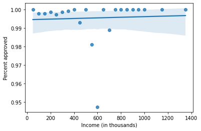

```python
income_graph = sns.regplot(income_x, income_y, fit_reg=True)
income_graph.set_xlabel("Income (in thousands)", fontsize = 10)
income_graph.set_ylabel("Percent approved", fontsize = 10)
print(income_graph)

income_table = pd.DataFrame(d_percent.items(), columns=['IncomeGroup', 'PercentApproved'])
income_regr = ols(formula = "PercentApproved ~ IncomeGroup", data = income_table).fit()
print(income_regr.summary())
```

We then modeled the data using a linear regression and we found that the coefficient slope number is 1.656e-06. This is also very small, smaller than the coefficient for age. Comparatively speaking, even though both coefficients are tiny, age seems to play a bigger role in the approval decision than income. However, this might not be completely accurate across the board for credit card approval and seems specific to this dataset. We say this because in this dataset, it looks like the majority of accepted applicants make upwards of $100K annually. Had the income distribution been a little more balanced, we infer that the correlation coefficient would have been larger.

## Working Years

Our hunch coming into this exploration of the influence of working years on approval was that the applicants that have worked for longer are more likely to be approved for a credit card as they are more likely to have a larger net worth and experience with money management.

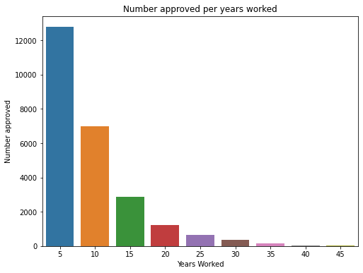

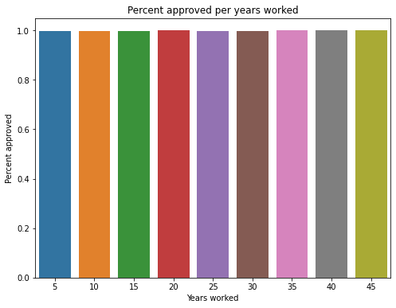

```python
employment_ranges = list(builtins.range(5, round(merged['YEARS_EMPLOYED'].max() + 5), 5))

d_approvals = defaultdict(int)
d_totals = defaultdict(int)

for idx, row in merged.iterrows():
  worked = row["YEARS_EMPLOYED"];
  approval = row["STATUS"];
  for val in employment_ranges:
    if worked <= val:
      d_totals[val] += 1
      if approval == "approved":
        d_approvals[val] += 1
      break

# Raw numbers graph
employment_x = list(d_approvals.keys())
employment_y = list(d_approvals.values())

plt.figure(figsize = (8,6))
sns.barplot(employment_x, employment_y)
plt.xlabel('Years Worked')
plt.ylabel('Number approved')
plt.title('Number approved per years worked')
plt.show()

print("\n")

# Percent graph
d_percent = {}
for key in d_totals.keys():
  d_percent[key] = d_approvals[key] / d_totals[key]

employment_x = list(d_percent.keys())
employment_y = list(d_percent.values())

plt.figure(figsize = (8,6))
sns.barplot(employment_x, employment_y)
plt.xlabel('Years worked')
plt.ylabel('Percent approved')
plt.title('Percent approved per years worked')
plt.show()
```

We followed the process from before with two graphs: 1) number of approved applicants in each range of years worked and 2) approval rate for each range.

Despite the first graph’s results (most accepted applicants had worked 0-5 years), the second graph gave us a slightly different result. For each range of years worked, the acceptance rate was either 100% or almost. It seems there might not be a significant correlation between years worked and acceptance alone.

```
AxesSubplot(0.125,0.125;0.775x0.755)
                            OLS Regression Results
==============================================================================
Dep. Variable:        PercentApproved   R-squared:                       0.434
Model:                            OLS   Adj. R-squared:                  0.353
Method:                 Least Squares   F-statistic:                     5.371
Date:                Mon, 16 May 2022   Prob (F-statistic):             0.0536
Time:                        19:31:39   Log-Likelihood:                 50.719
No. Observations:                   9   AIC:                            -97.44
Df Residuals:                       7   BIC:                            -97.04
Df Model:                           1
Covariance Type:            nonrobust
===================================================================================
                      coef    std err          t      P>|t|      [0.025      0.975]
-----------------------------------------------------------------------------------
Intercept           0.9973      0.001   1401.839      0.000       0.996       0.999
EmploymentGroup   5.86e-05   2.53e-05      2.318      0.054   -1.19e-06       0.000
==============================================================================
Omnibus:                        4.152   Durbin-Watson:                   2.622
Prob(Omnibus):                  0.125   Jarque-Bera (JB):                0.889
Skew:                          -0.640   Prob(JB):                        0.641
Kurtosis:                       3.854   Cond. No.                         61.4
==============================================================================

Warnings:
[1] Standard Errors assume that the covariance matrix of the errors is correctly specified.
```

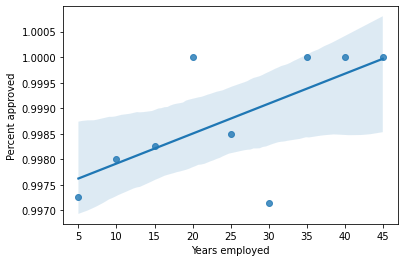

```python
# working years (trend longer you have worked more likely)
employment_graph = sns.regplot(employment_x, employment_y, fit_reg=True)
employment_graph.set_xlabel("Years employed", fontsize = 10)
employment_graph.set_ylabel("Percent approved", fontsize = 10)
print(employment_graph)

employment_table = pd.DataFrame(d_percent.items(), columns=['EmploymentGroup', 'PercentApproved'])
employment_regr = ols(formula = "PercentApproved ~ EmploymentGroup", data = employment_table).fit()
print(employment_regr.summary())
```

In the linear regression model, we found that the coefficient slope number is 5.86e-05. While this is a small coefficient, it is the largest one we’ve encountered thus far. This means in the context of this dataset, the number of years an applicant has worked is a more important factor in their approval decision than the applicant’s age and income. Generally, the longer someone has been employed, the greater the chance that they’re approved for a credit card.

## Education

With this specific category, we weren’t necessarily too sure how the level of education of an applicant would factor into the approval decision. Since the possible values for this column in the original table were string objects, we first converted them into numerical values. "Lower secondary" education became 0. "Secondary / secondary special" education became 1. "Incomplete higher" education became 2. "Higher education" became 3. Then, we implemented the same procedure as before and produced two graphs.

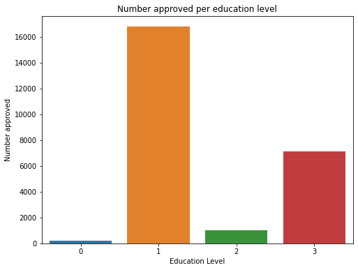

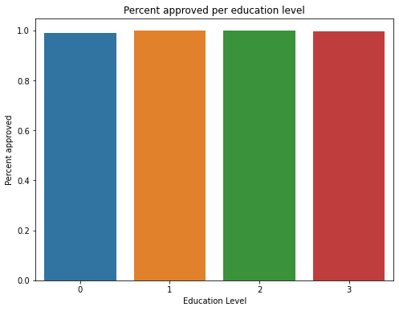

```python
# Education (lower vs higher education)
edu_table = merged.copy()
edu_table.loc[edu_table["NAME_EDUCATION_TYPE"] == "Academic degree", "NAME_EDUCATION_TYPE"] = "Higher education"
# NAME_EDUCATION_TYPE:
# ['Lower secondary', 'Secondary / secondary special', 'Incomplete higher', 'Higher education'] => [0, 1, 2, 3]
edu_table["NAME_EDUCATION_TYPE"].replace({"Lower secondary": 0, "Secondary / secondary special": 1, "Incomplete higher": 2, "Higher education": 3}, inplace=True)

d_approvals = defaultdict(int)
d_totals = defaultdict(int)
for idx, row in edu_table.iterrows():
  education = row["NAME_EDUCATION_TYPE"];
  approval = row["STATUS"];
  d_totals[education] += 1
  if approval == "approved":
    d_approvals[education] += 1


# Raw numbers graph
education_x = list(d_approvals.keys())
education_y = list(d_approvals.values())

plt.figure(figsize = (8,6))
sns.barplot(education_x, education_y)
plt.xlabel('Education Level')
plt.ylabel('Number approved')
plt.title('Number approved per education level')
plt.show()

print("\n")

# Percent graph
d_percent = {}
for key in d_totals.keys():
  d_percent[key] = d_approvals[key] / d_totals[key]

education_x = list(d_percent.keys())
education_y = list(d_percent.values())

plt.figure(figsize = (8,6))
sns.barplot(education_x, education_y)
plt.xlabel('Education Level')
plt.ylabel('Percent approved')
plt.title('Percent approved per education level')
plt.show()
```

With the first graph, we learned that the group that completed secondary education had the highest number of approved applicants within the four levels of education. The second graph showed us that for each group, the acceptance rate was nearly 100%. This particular category will be interesting in hypothesis testing.

```
AxesSubplot(0.125,0.125;0.775x0.755)
                            OLS Regression Results
==============================================================================
Dep. Variable:        PercentApproved   R-squared:                       0.474
Model:                            OLS   Adj. R-squared:                  0.211
Method:                 Least Squares   F-statistic:                     1.802
Date:                Mon, 16 May 2022   Prob (F-statistic):              0.312
Time:                        19:31:42   Log-Likelihood:                 17.852
No. Observations:                   4   AIC:                            -31.70
Df Residuals:                       2   BIC:                            -32.93
Df Model:                           1
Covariance Type:            nonrobust
==================================================================================
                     coef    std err          t      P>|t|      [0.025      0.975]
----------------------------------------------------------------------------------
Intercept          0.9923      0.003    300.629      0.000       0.978       1.006
EducationLevel     0.0024      0.002      1.343      0.312      -0.005       0.010
==============================================================================
Omnibus:                          nan   Durbin-Watson:                   2.566
Prob(Omnibus):                    nan   Jarque-Bera (JB):                0.570
Skew:                           0.098   Prob(JB):                        0.752
Kurtosis:                       1.162   Cond. No.                         3.76
==============================================================================

Warnings:
[1] Standard Errors assume that the covariance matrix of the errors is correctly specified.
```

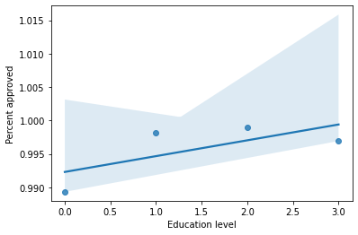

```python
education_graph = sns.regplot(education_x, education_y, fit_reg=True)
education_graph.set_xlabel("Education level", fontsize = 10)
education_graph.set_ylabel("Percent approved", fontsize = 10)
print(education_graph)

education_table = pd.DataFrame(d_percent.items(), columns=['EducationLevel', 'PercentApproved'])
education_regr = ols(formula = "PercentApproved ~ EducationLevel", data = education_table).fit()
print(education_regr.summary())
```

While the graphs weren’t especially enlightening in this case, the linear regression model gives us greater insight into how much an applicant’s level of education affects their likelihood of being approved for a credit card. The correlation coefficient of the model for education is 0.0024! This is much, much larger than the coefficients for age, income, and work experience. The higher the applicant’s level of education is, the more likely they are to be approved for a credit card.

## Marital Status

Prior to graphing, we predicted that married applicants would have the highest approval rate of the different marital status'.

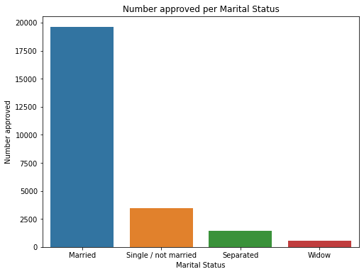

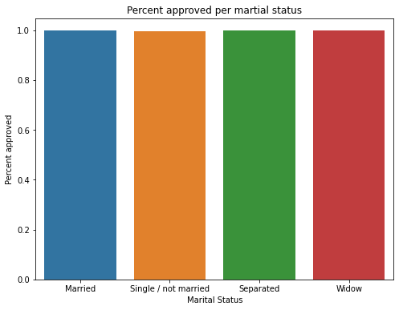

```python
# Marriage Condition
marriage_table = merged.copy()
marriage_table.loc[marriage_table["NAME_FAMILY_STATUS"] == "Civil marriage", "NAME_FAMILY_STATUS"] = "Married"

d_approvals = defaultdict(int)
d_totals = defaultdict(int)
for idx, row in marriage_table.iterrows():
  marital_status = row["NAME_FAMILY_STATUS"];
  approval = row["STATUS"];
  d_totals[marital_status] += 1
  if approval == "approved":
    d_approvals[marital_status] += 1

# Raw numbers graph
marriage_x = list(d_approvals.keys())
marriage_y = list(d_approvals.values())

plt.figure(figsize = (8,6))
sns.barplot(marriage_x, marriage_y)
plt.xlabel('Marital Status')
plt.ylabel('Number approved')
plt.title('Number approved per Marital Status')
plt.show()

print("\n")

# Percent graph
d_percent = {}
for key in d_totals.keys():
  d_percent[key] = d_approvals[key] / d_totals[key]

marital_x = list(d_percent.keys())
marital_y = list(d_percent.values())

plt.figure(figsize = (8,6))
sns.barplot(marital_x, marital_y)
plt.xlabel('Marital Status')
plt.ylabel('Percent approved')
plt.title('Percent approved per martial status')
plt.show()
```

```python
d_percent
```

```
{'Married': 0.9981162814377355,
 'Separated': 0.9972733469665985,
 'Single / not married': 0.9959361393323658,
 'Widow': 0.9982758620689656}
```

# **Conclusion**

Given the results of fitting our data in various linear regression models, we see that our hypothesis was wrong. It is evident that education has the greatest influence on the credit card approval of the five factors examined. This is not to say that the other factors (that weren’t explored with the same depth as age, income, amount of work experience, education, and marital status) are unimportant. From the linear discriminant analysis, we saw that including all the different factors yielded the correct approval prediction with 99.65% accuracy. While we understand that the real-world approach that credit card companies utilize to automate the approval process is much more thorough and complex, it was still an enlightening experience to figure out and replicate this process on a smaller dataset.